# Module18 Notes

Dani Antos

November 9, 2017

There are many types of mixed modeling:

- linear mixed models (LMM): dealing with normally distributed variables and error structures
- generalized linear mixed models (GLMM): other variable types and error structure
- nonlinear mixed models (NLMM): situations where the response variable is modeled by a nonlinear combination of predictors; ex. Chris uses NLMMs to model somatic growth in monkeys

In both types of linear mixed models, we have response variable Y and observations that fall into different categories with a set of levels (male and female, for example). We want to see the effects of the factors and factor levels on the response variable

- if mu=population mean and mu(A)=mean response for observations in factor level A, then the effect of A=mu-mu(A)
- we looked at factors and factor levels already with ANOVAs and ANCOVAs

factor effects can be **fixed** or **random**

1. fixed factors reflect all levels of interest in the study
2. random effects only represent a sample of the levels of interest
- ex. if sex is a factor with factor levels of male and female, it is a fixed factor because it will cover all levels of interest
- ex. if individual id was the factor, it would probably be a random factor because we wouldn’t collecct data from all possible individual subjects

**Mixed models** include BOTH fixed and random effects. Including random effects has several ramifications

- random effects broaden the scope of inference
- using random effects naturally incorporate dependence in the model, helps us account for pseudoreplication in our dataset. Observations that are in the same level of the random effects are modeled as being correlated, useful in time series data and spatially correlated data
- random factors give more accurate parameter estimates
- requires use of more sophisticated estimation and fitting methods

# Example

We’re measuring the amount of grooming received by female chimpanzees when they are ovulating versus the rest of their reproductive cycle

- factors are duration of grooming bouts received and the female’s reproductive condition
- the second one is a categorical variable with two levels : POP and NONPOP
- there was also data on whether the female had previously given birth, called parity. Categorical variable with 2 levels: parous, P, or nulliparous, N

The regression model should look like this:

grooming duration ~ condition + parity + error

We’re assuming that we took multiple observations per subject (multiple bouts of grooming), this violated the **independence of observations** needed for a standard linear regression

- we can deal with this by adding a *subject ID* as a random effect in our model
- we can estimate a different set of parameters ofor each level of a factor. We can estimate a different intercept for each one OR a different intercept and slope for each level
- the model estimates the main effects of each variable as well as these individual level parameters
- including the random effects in with the fixed effects is what makes this a mixed model

## Challenge

```r
library(curl)
f <- curl("https://raw.githubusercontent.com/fuzzyatelin/fuzzyatelin.github.io/master/AN597_Fall17/chimpgrooming.csv")
d <- read.csv(f, header = TRUE, sep = ",")
head(d)
```

```
##   subject parity season reprocondition duration
## 1    Nina      P     WS         NONPOP   213.56
## 2    Nina      P     WS            POP   205.81
## 3    Nina      P     WS         NONPOP   293.71
## 4    Nina      P     WS            POP   268.76
## 5    Nina      P     WS         NONPOP   205.02
## 6    Nina      P     WS            POP   287.19
```

```r
summary(d)
```

```
##   subject   parity season  reprocondition    duration
##  Luna :14   N:42   DS:48   NONPOP:42      Min.   : 86.34
##  Maya :14   P:42   WS:36   POP   :42      1st Qu.:132.36
##  Nina :14                                 Median :205.41
##  Nipa :14                                 Mean   :197.81
##  Sofia:14                                 3rd Qu.:252.27
##  Vita :14                                 Max.   :316.23
```

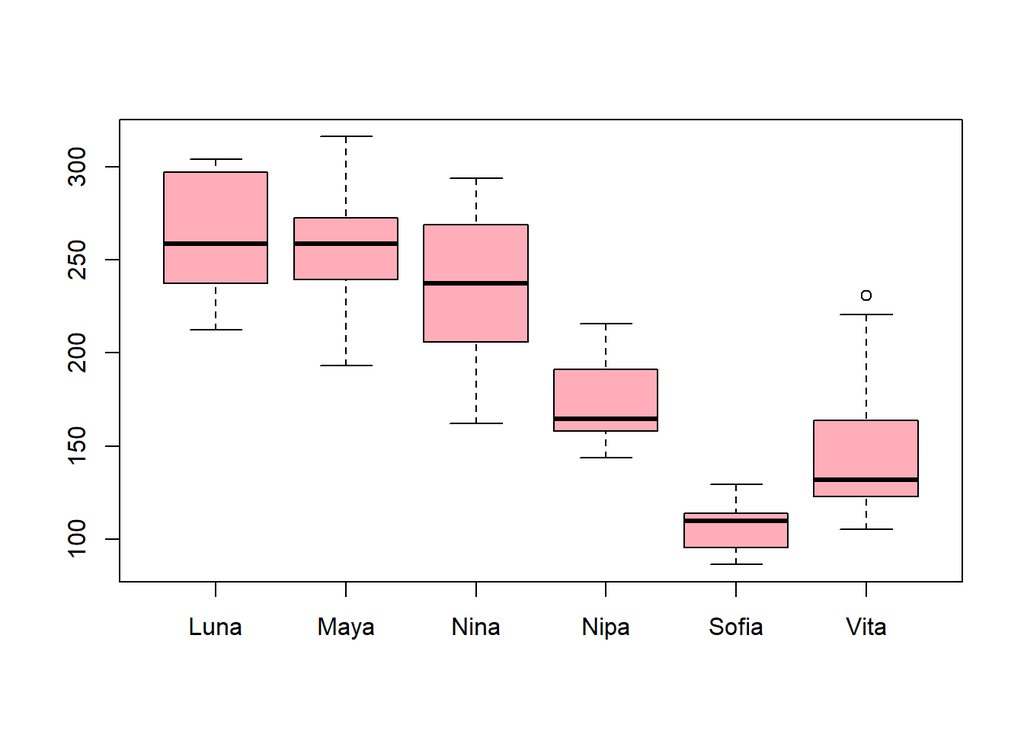

```r
# first, some exploratory visualization let's plot grooming received
# duration in relation to subject ID
par(mfrow = c(1, 1))
boxplot(data = d, duration ~ subject, col = c("lightpink1"))
```

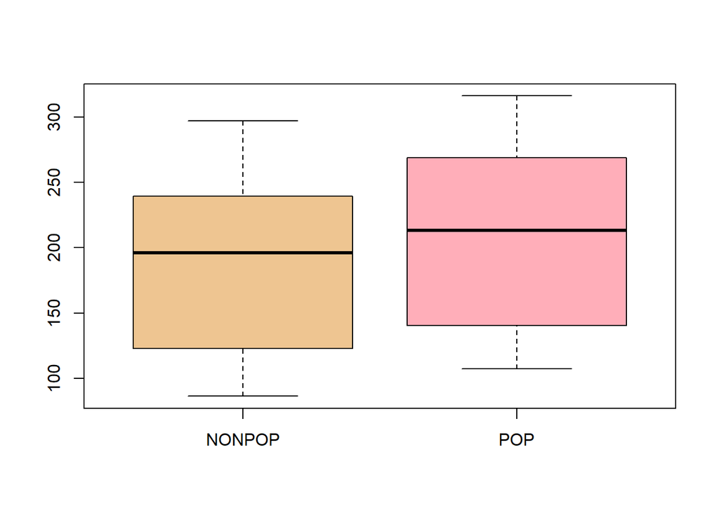

```r
# we see lots of individual variation let's plot grooming received duration
# in relation to reproductive condition
boxplot(data = d, duration ~ reprocondition, col = c("burlywood2", "lightpink1"))
```

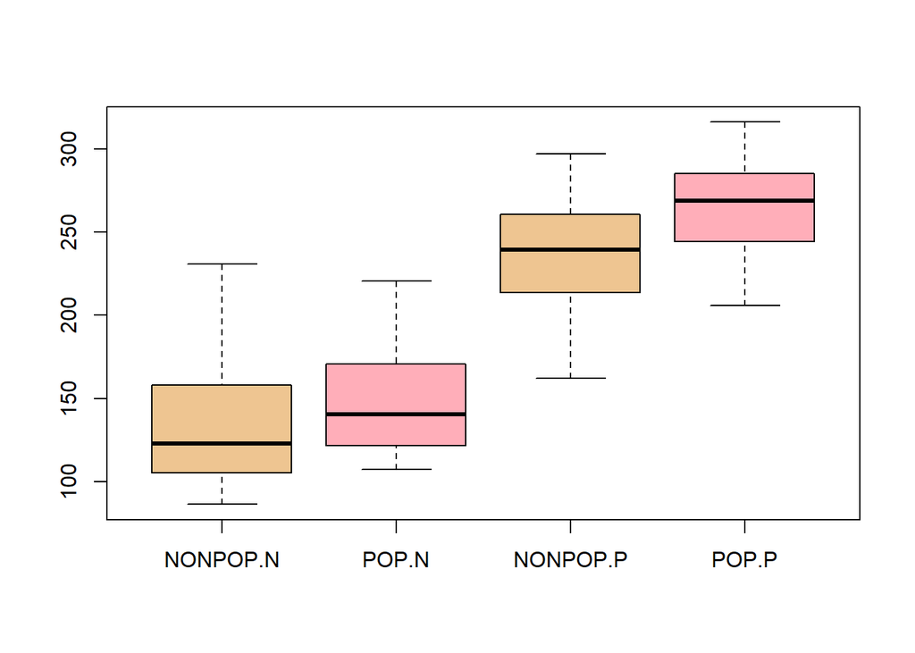

```r
# let's plot grooming received duration in relation to reproductive
# condition and parity
boxplot(data = d, duration ~ reprocondition * parity, col = c("burlywood2", "lightpink1"))
```

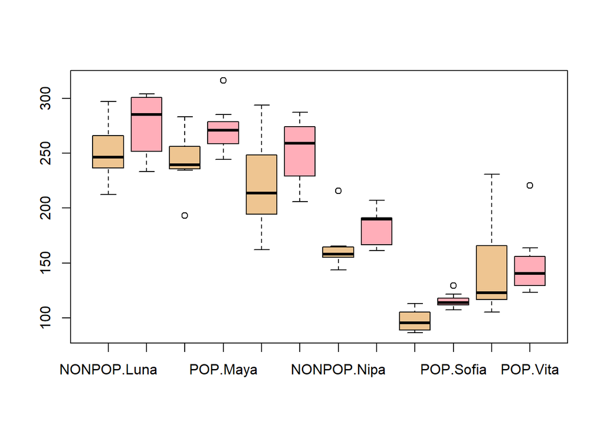

```r
boxplot(data = d, duration ~ reprocondition * subject, col = c("burlywood2", "lightpink1"))
```

Luna is highest regardless of other variables, Sofia is lowest regardless of other variables. P is higher than N.

## Random Intercept Models

We’re running a mixed effect analysis where:

- we look at how reproductive condition and parity effect grooming duration
- parity is a fixed effect
- subject ID is a random effect

Here’s our model:

grooming duration ~ condition + parity + (1|subjecct) + error

(1|subject)- let’s talk about it.

- 1 means that we want to estimate an intercept, and the vertical line means that we want a different intercept for each subject.
- we will still have some unexplained error after accounting for the fixed and random effects in the model
- the formula is basically saying that we are expecting multiple response variable observations per subject and the responses will partially depend on the subject’s baseline levels== accounts for **nonindependence**
- {lme4} is commonly used for mixed modeling and lmer() function is the mixed model equivalent to lm() hell yeah man
- **syntax note**: fixed effects are included without parenthesis but random effects are included with parenthesis. Error is assumed, so not explicitly required; {lme4} uses **restricted maximum likelihood** rather than ordinary maximum likelihood estimation, unless otherwise specified.

```r
library(lme4)
lme <- lmer(data = d, duration ~ reprocondition + parity + (1 | subject))
summary(lme)
```

```
## Linear mixed model fit by REML ['lmerMod']
## Formula: duration ~ reprocondition + parity + (1 | subject)
##    Data: d
##
## REML criterion at convergence: 796.1
##
## Scaled residuals:
##     Min      1Q  Median      3Q     Max
## -2.2611 -0.5349 -0.1890  0.3918  3.1994
##
## Random effects:
##  Groups   Name        Variance Std.Dev.
##  subject  (Intercept) 611.9    24.74
##  Residual             847.3    29.11
## Number of obs: 84, groups:  subject, 6
##
## Fixed effects:
##                   Estimate Std. Error t value
## (Intercept)        132.841     15.305   8.680
## reproconditionPOP   20.293      6.352   3.195
## parityP            109.650     21.173   5.179
##
## Correlation of Fixed Effects:
##             (Intr) rprPOP
## rprcndtnPOP -0.208
## parityP     -0.692  0.000
```

```r
coefficients(lme)
```

```
## $subject
##       (Intercept) reproconditionPOP parityP
## Luna    142.76558          20.29286  109.65
## Maya    137.37902          20.29286  109.65
## Nina    118.37755          20.29286  109.65
## Nipa    160.80050          20.29286  109.65
## Sofia    99.80117          20.29286  109.65
## Vita    137.92047          20.29286  109.65
##
## attr(,"class")
## [1] "coef.mer"
```

1. output of the random effects (in this case: SUBJECT): “subject” in the standard deviation column shows how much variability in grooming duration is explained by subject ID, not including the variability explained by the fixed effects. “Residual” makes up the rest of the variability.
2. fixed effect output:
- looks pretty similar to lm() coefficient tables. “reproconditionPOP” is the slope for the effect of reproductive condition, meaning that the grooming duration is greater by ~20 units for POP than NONPOP females. We also have a standard error and a t value.
- “parityP” is the beta coefficient for parity (categorical variable). Grooming duration for parous females is 109 untis greater than for nulliparous females.
- the *intercept* is the grooming duration associated with nulliparous, NONPOP females (because it’s considererd the baseline)

## Statistical Significance

p values aren’t as straightforward to determine in mixed effects models. We can use “likelihood ratio tests” to overcome this difficulty because it compares the likelihood of two models with each other, so like a full model versus a reduced, nested model excluding a particular factor

### Example

Two models that we could compare:

- grooming duration ~ condition + parity +(1|subject) + error
- grooming duration ~ parity + (1|subject) + error

```r
full <- lmer(data = d, duration ~ reprocondition + parity + (1 | subject), REML = FALSE) #REML = FALSE is necessary for a likelihood ratio test because it requires ordinary likelihood, not the altered algorithm used for REML
summary(full)
```

```
## Linear mixed model fit by maximum likelihood  ['lmerMod']
## Formula: duration ~ reprocondition + parity + (1 | subject)
##    Data: d
##
##      AIC      BIC   logLik deviance df.resid
##    825.7    837.9   -407.9    815.7       79
##
## Scaled residuals:
##     Min      1Q  Median      3Q     Max
## -2.2996 -0.5283 -0.1783  0.4032  3.2285
##
## Random effects:
##  Groups   Name        Variance Std.Dev.
##  subject  (Intercept) 388.6    19.71
##  Residual             836.4    28.92
## Number of obs: 84, groups:  subject, 6
##
## Fixed effects:
##                   Estimate Std. Error t value
## (Intercept)        132.841     12.625  10.522
## reproconditionPOP   20.293      6.311   3.215
## parityP            109.650     17.288   6.343
##
## Correlation of Fixed Effects:
##             (Intr) rprPOP
## rprcndtnPOP -0.250
## parityP     -0.685  0.000
```

```r
reduced <- lmer(data = d, duration ~ parity + (1 | subject), REML = FALSE)
summary(reduced)
```

```
## Linear mixed model fit by maximum likelihood  ['lmerMod']
## Formula: duration ~ parity + (1 | subject)
##    Data: d
##
##      AIC      BIC   logLik deviance df.resid
##    833.4    843.2   -412.7    825.4       80
##
## Scaled residuals:
##     Min      1Q  Median      3Q     Max
## -2.4996 -0.6492 -0.1198  0.6594  2.7072
##
## Random effects:
##  Groups   Name        Variance Std.Dev.
##  subject  (Intercept) 380.6    19.51
##  Residual             947.3    30.78
## Number of obs: 84, groups:  subject, 6
##
## Fixed effects:
##             Estimate Std. Error t value
## (Intercept)   142.99      12.22  11.697
## parityP       109.65      17.29   6.343
##
## Correlation of Fixed Effects:
##         (Intr)
## parityP -0.707
```

```r
#anova() function is used to perform likelihood ratio test
anova(reduced, full, test = "Chisq")
```

```
## Data: d
## Models:
## reduced: duration ~ parity + (1 | subject)
## full: duration ~ reprocondition + parity + (1 | subject)
##         Df    AIC    BIC  logLik deviance  Chisq Chi Df Pr(>Chisq)
## reduced  4 833.43 843.15 -412.72   825.43
## full     5 825.72 837.88 -407.86   815.72 9.7089      1   0.001834 **
## ---
## Signif. codes:  0 '***' 0.001 '**' 0.01 '*' 0.05 '.' 0.1 ' ' 1
```

The results show that the model WITH reproductive condition fits the data better than the null model excluding this variable

### Example

What if we compare two models with and without **parity**?

```r
full <- lmer(data = d, duration ~ reprocondition + parity + (1 | subject), REML = FALSE)
reduced <- lmer(data = d, duration ~ reprocondition + (1 | subject), REML = FALSE)
anova(reduced, full, test = "Chisq")
```

```
## Data: d
## Models:
## reduced: duration ~ reprocondition + (1 | subject)
## full: duration ~ reprocondition + parity + (1 | subject)
##         Df    AIC    BIC  logLik deviance  Chisq Chi Df Pr(>Chisq)
## reduced  4 835.97 845.70 -413.99   827.97
## full     5 825.72 837.88 -407.86   815.72 12.251      1   0.000465 ***
## ---
## Signif. codes:  0 '***' 0.001 '**' 0.01 '*' 0.05 '.' 0.1 ' ' 1
```

Parity also significantly improves the fit of our model. What are we looking at to decide this again?

## Challenge

We want a model that includes interations of reproductive condition and parity and COMPARE it to a model without the interaction of these terms. Is the interaction significant?

```r
full <- lmer(data = d, duration ~ reprocondition * parity + (1 | subject), REML = FALSE)
reduced <- lmer(data = d, duration ~ reprocondition + parity + (1 | subject),
    REML = FALSE)
anova(reduced, full, test = "Chisq")
```

```
## Data: d
## Models:
## reduced: duration ~ reprocondition + parity + (1 | subject)
## full: duration ~ reprocondition * parity + (1 | subject)
##         Df    AIC    BIC  logLik deviance  Chisq Chi Df Pr(>Chisq)
## reduced  5 825.72 837.88 -407.86   815.72
## full     6 826.41 840.99 -407.20   814.41 1.3124      1      0.252
```

## Random Slope Models

Previously, we assumed that the relationship between grooming duration and reproductive condition + parity was the same for all females, but that could be false. We can use random slope models to allow the relationship to vary among subjects.

```r
lme <- lmer(data = d, duration ~ reprocondition + parity + (1 + reprocondition | subject) + (1 + parity | subject), REML = FALSE)
summary(lme)
```

```
## Linear mixed model fit by maximum likelihood  ['lmerMod']
## Formula:
## duration ~ reprocondition + parity + (1 + reprocondition | subject) +
##     (1 + parity | subject)
##    Data: d
##
##      AIC      BIC   logLik deviance df.resid
##    833.6    857.9   -406.8    813.6       74
##
## Scaled residuals:
##     Min      1Q  Median      3Q     Max
## -2.4514 -0.6093 -0.1559  0.3851  3.2152
##
## Random effects:
##  Groups    Name              Variance Std.Dev. Corr
##  subject   (Intercept)        83.992   9.165
##            reproconditionPOP   1.466   1.211   -1.00
##  subject.1 (Intercept)       628.511  25.070
##            parityP           628.514  25.070   -1.00
##  Residual                    835.802  28.910
## Number of obs: 84, groups:  subject, 6
##
## Fixed effects:
##                   Estimate Std. Error t value
## (Intercept)        132.530     16.294   8.134
## reproconditionPOP   20.293      6.328   3.207
## parityP            110.271     17.258   6.389
##
## Correlation of Fixed Effects:
##             (Intr) rprPOP
## rprcndtnPOP -0.211
## parityP     -0.902  0.000
```

```r
coefficients(lme)
```

```
## $subject
##       (Intercept) reproconditionPOP   parityP
## Luna     144.8584          19.47836 110.27129
## Maya     137.6454          19.95490 110.27122
## Nina     113.0913          21.57714 110.27100
## Nipa     139.1936          19.85262  84.76947
## Sofia    125.3346          20.76825 140.07661
## Vita     135.0575          20.12588 105.96742
##
## attr(,"class")
## [1] "coef.mer"
```

```r
# reproductive condition
full <- lmer(data = d, duration ~ reprocondition + parity + (1 + reprocondition |
    subject) + (1 + parity | subject), REML = FALSE)
reduced <- lmer(data = d, duration ~ parity + (1 + reprocondition | subject) +
    (1 + parity | subject), REML = FALSE)
anova(reduced, full, test = "Chisq")
```

```
## Data: d
## Models:
## reduced: duration ~ parity + (1 + reprocondition | subject) + (1 + parity |
## reduced:     subject)
## full: duration ~ reprocondition + parity + (1 + reprocondition | subject) +
## full:     (1 + parity | subject)
##         Df    AIC    BIC  logLik deviance  Chisq Chi Df Pr(>Chisq)
## reduced  9 840.23 862.11 -411.11   822.23
## full    10 833.63 857.94 -406.82   813.63 8.5963      1   0.003368 **
## ---
## Signif. codes:  0 '***' 0.001 '**' 0.01 '*' 0.05 '.' 0.1 ' ' 1
```

```r
# parity
full <- lmer(data = d, duration ~ reprocondition + parity + (1 + reprocondition |
    subject) + (1 + parity | subject), REML = FALSE)
null <- lmer(data = d, duration ~ reprocondition + (1 + reprocondition | subject) +
    (1 + parity | subject), REML = FALSE)
```

```
## Warning in checkConv(attr(opt, "derivs"), opt$par, ctrl = control$checkConv, : Model is nearly unidentifiable: large eigenvalue ratio
##  - Rescale variables?
```

```r
anova(reduced, full, test = "Chisq")
```

```
## Data: d
## Models:
## reduced: duration ~ parity + (1 + reprocondition | subject) + (1 + parity |
## reduced:     subject)
## full: duration ~ reprocondition + parity + (1 + reprocondition | subject) +
## full:     (1 + parity | subject)
##         Df    AIC    BIC  logLik deviance  Chisq Chi Df Pr(>Chisq)
## reduced  9 840.23 862.11 -411.11   822.23
## full    10 833.63 857.94 -406.82   813.63 8.5963      1   0.003368 **
## ---
## Signif. codes:  0 '***' 0.001 '**' 0.01 '*' 0.05 '.' 0.1 ' ' 1
```

The random effects are a little different now: the new notation means that we want to estimate different baseline levels of grooming duration as well as differing responses to the main factor (which is the term before the ‘|’ in the code). Now, each female has a different intercept AND a different slope coefficient for grooming duration as a function of reproductive condition and parity.

Now we can get p values for our fixed factors using LRTs, but we get warnings that our null models fail to converge. This can be due to having a lot of parameters that we’re trying to estimate, like more than the number of observations we have.

## Determining Model Fit

With today’s knowledge, instead of doing everything we just did above, we can assess a model’s fit using AIC. **NOTE**: AIC can only give us a relative fit, not whether a model is an overall good fit.

But wait, again! Now we have a simple way to get an Rsquared value for GLMMs. They propose a **marginal Rsquared** which is variance that is explained on the latent scale instead of the original scale, aka variance explained by only the fixed effects. There’s also **conditional Rsquared** which is variance explained by fixed and random effects, aka variance expained by the whole model.

{MuMIn} package gives us a function that calculates these super cool super new Rsquared values: r.squaredGLMM()

### Challenge

Compare full, reduced, and null models from the random slope exercise using the new methods. Which model has the best fit?

```r
library(AICcmodavg)
print(aictab(list(full, reduced, null), c("full", "reduced", "null")), LL = FALSE) #ERROR: null not found
```

```
##
## Model selection based on AICc:
##
##          K   AICc Delta_AICc AICcWt Cum.Wt
## full    10 836.65       0.00   0.95   0.95
## reduced  9 842.66       6.02   0.05   1.00
## null     9 847.39      10.75   0.00   1.00
```

```r
library(MuMIn)
r.squaredGLMM(full)
```

```
##       R2m       R2c
## 0.7221698 0.8102361
```

```r
r.squaredGLMM(reduced)
```

```
##       R2m       R2c
## 0.6778129 0.7898004
```

```r
r.squaredGLMM(null)
```

```
##        R2m        R2c
## 0.01687825 0.86465307
```